# Ford GoBike System Data

## by Mostafa Mohamed Mahmoud Abdelghafaar

## Preliminary Wrangling

> This data set includes information about individual rides made in a bike-sharing system covering the greater San Francisco Bay area.

```python
# import all packages and set plots to be embedded inline
import numpy as np
import pandas as pd
import matplotlib.pyplot as plt
import seaborn as sb

%matplotlib inline
```

> Load in your dataset and describe its properties through the questions below. Try and motivate your exploration goals through this section.

```python
# Read data in fordgobike
df = pd.read_csv('201902-fordgobike-tripdata.csv')
df.head()
```

|  | duration_sec | start_time | end_time | start_station_id | start_station_name | start_station_latitude | start_station_longitude | end_station_id | end_station_name | end_station_latitude | end_station_longitude | bike_id | user_type | member_birth_year | member_gender | bike_share_for_all_trip |
| --- | --- | --- | --- | --- | --- | --- | --- | --- | --- | --- | --- | --- | --- | --- | --- | --- |
| 0 | 52185 | 32:10.1 | 01:56.0 | 21.0 | Montgomery St BART Station (Market St at 2nd St) | 37.789625 | -122.400811 | 13.0 | Commercial St at Montgomery St | 37.794231 | -122.402923 | 4902 | Customer | 1984.0 | Male | No |
| 1 | 42521 | 53:21.8 | 42:03.1 | 23.0 | The Embarcadero at Steuart St | 37.791464 | -122.391034 | 81.0 | Berry St at 4th St | 37.775880 | -122.393170 | 2535 | Customer | NaN | NaN | No |
| 2 | 61854 | 13:13.2 | 24:08.1 | 86.0 | Market St at Dolores St | 37.769305 | -122.426826 | 3.0 | Powell St BART Station (Market St at 4th St) | 37.786375 | -122.404904 | 5905 | Customer | 1972.0 | Male | No |
| 3 | 36490 | 54:26.0 | 02:36.8 | 375.0 | Grove St at Masonic Ave | 37.774836 | -122.446546 | 70.0 | Central Ave at Fell St | 37.773311 | -122.444293 | 6638 | Subscriber | 1989.0 | Other | No |
| 4 | 1585 | 54:18.5 | 20:44.1 | 7.0 | Frank H Ogawa Plaza | 37.804562 | -122.271738 | 222.0 | 10th Ave at E 15th St | 37.792714 | -122.248780 | 4898 | Subscriber | 1974.0 | Male | Yes |

```python
# Show number of rows and columns
df.shape
```

```
(183412, 16)
```

```python
# Datatypes for every column
df.dtypes
```

```
duration_sec                 int64
start_time                  object
end_time                    object
start_station_id           float64
start_station_name          object
start_station_latitude     float64
start_station_longitude    float64
end_station_id             float64
end_station_name            object
end_station_latitude       float64
end_station_longitude      float64
bike_id                      int64
user_type                   object
member_birth_year          float64
member_gender               object
bike_share_for_all_trip     object
dtype: object
```

```python
# Number of station exists
print(df['start_station_name'].nunique())
```

```
329
```

```python
# Number of null values in each col
df.isnull().sum()
```

```
duration_sec                  0
start_time                    0
end_time                      0
start_station_id            197
start_station_name          197
start_station_latitude        0
start_station_longitude       0
end_station_id              197
end_station_name            197
end_station_latitude          0
end_station_longitude         0
bike_id                       0
user_type                     0
member_birth_year          8265
member_gender              8265
bike_share_for_all_trip       0
dtype: int64
```

### What is the structure of your dataset?

> There are (183412, 16) in the dataset with 16 features

> duration_sec int64 start_time object end_time object start_station_id float64 start_station_name object start_station_latitude float64 start_station_longitude float64 end_station_id float64 end_station_name object end_station_latitude float64 end_station_longitude float64 bike_id int64 user_type object member_birth_year float64 member_gender object bike_share_for_all_trip object

> Most variables are numeric in nature, And number of stations are 329 station.

### What is/are the main feature(s) of interest in your dataset?

> I'm most interested in finding out what attracts individual rides take part in a bike-sharing system in the dataset.

### What features in the dataset do you think will help support your investigation into your feature(s) of interest?

> I expect duratin for trip may help me know which is prefer at most for riders ,,and that riders prefer particular stations than others so i will use (start_station_id or start_station_name) to explore that ,, and male or females are most expiried for this ,, and age of participants ,, and user type which participate at most Customer or Subscriber ,, explore if most of using is for bike_share_for_all_trip or not.

## Univariate Exploration

> In this section, investigate distributions of individual variables. If you see unusual points or outliers, take a deeper look to clean things up and prepare yourself to look at relationships between variables.

```python
def display_histplot(df, variable, binsize, xlabel, ylabel, title):
    """
        This function for visulize data in bar plot
    """
    bins = np.arange(0, df[variable].max()+binsize, binsize)

    plt.figure(figsize=[10, 8])
    plt.hist(data = df, x = variable, bins = bins)
    plt.xlabel(xlabel)
    plt.ylabel(ylabel)
    plt.title(title)
```

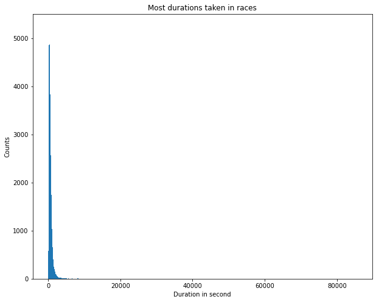

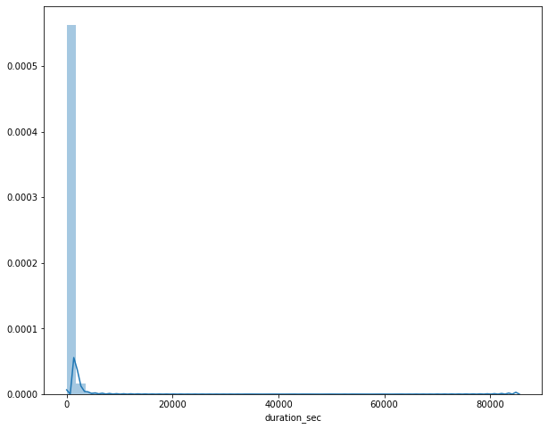

```python
# Show most durations in races
binsize = 20
display_histplot(df, 'duration_sec', binsize, 'Duration in second', 'Counts', 'Most durations taken in races')

plt.figure(figsize=[10, 8])
sb.distplot(df['duration_sec'])
```

[output not shown]

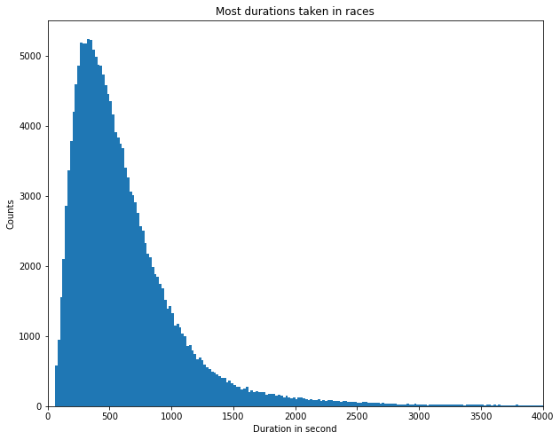

```python
# Made visulization more focused
binsize = 20
display_histplot(df, 'duration_sec', binsize, 'Duration in second', 'Counts', 'Most durations taken in races')
plt.xlim(0, 4000)
```

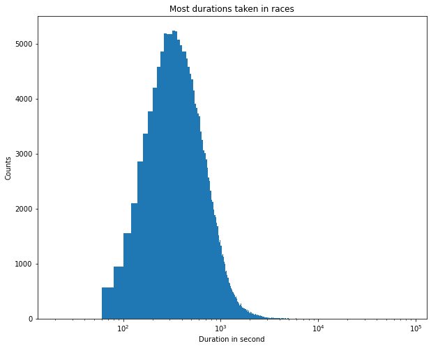

```python
# there's a long tail in the distribution, so let's put it on a log scale instead
log_binsize = 0.025
bins = 10 ** np.arange(2.4, np.log10(df['duration_sec'].max())+log_binsize, log_binsize)
display_histplot(df, 'duration_sec', binsize, 'Duration in second', 'Counts', 'Most durations taken in races')
plt.xscale('log')
```

```python
#Get average of duration less than 1500
df[df['duration_sec']<1500]['duration_sec'].mean()
```

```
553.4979998268249
```

> It's consider that duration above 1500 is outliers and observed that most riders prefer time duration in Average 550 second.

```
Male      130651
Female     40844
Other       3652
Name: member_gender, dtype: int64
```

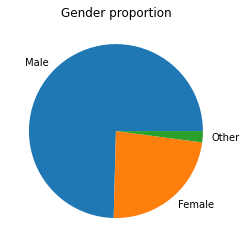

```python
#visulization show us each gender proportion in particpating in races
df_gender=df['member_gender'].dropna()
df_sorted = df_gender.value_counts()
print(df_sorted)
plt.pie(df_sorted, labels=df_sorted.index);
plt.title('Gender proportion')
```

> Most of peoples are Males and The remainder nearly represent a quarter of the percentage of participants are females and others.

```python
# Number of people in each start station
df_station=df['start_station_name'].dropna()
df_sorted = df_station.value_counts()
print(df_sorted[0:20])
```

```
Market St at 10th St                                               3904
San Francisco Caltrain Station 2  (Townsend St at 4th St)          3544
Berry St at 4th St                                                 3052
Montgomery St BART Station (Market St at 2nd St)                   2895
Powell St BART Station (Market St at 4th St)                       2760
San Francisco Ferry Building (Harry Bridges Plaza)                 2710
San Francisco Caltrain (Townsend St at 4th St)                     2703
Powell St BART Station (Market St at 5th St)                       2327
Howard St at Beale St                                              2293
Steuart St at Market St                                            2283
The Embarcadero at Sansome St                                      2082
Bancroft Way at Telegraph Ave                                      1796
Bancroft Way at College Ave                                        1770
2nd St at Townsend St                                              1765
3rd St at Townsend St                                              1753
Embarcadero BART Station (Beale St at Market St)                   1746
Beale St at Harrison St                                            1719
Civic Center/UN Plaza BART Station (Market St at McAllister St)    1611
Townsend St at 7th St                                              1573
4th St at Mission Bay Blvd S                                       1552
Name: start_station_name, dtype: int64
```

```python
#Cut dataframe for top 10 stations of number of riders
Top_df = df[(df['start_station_name']=="Market St at 10th St") | (df['start_station_name']=="San Francisco Caltrain Station 2  (Townsend St at 4th St)") | (df['start_station_name']=="Berry St at 4th St") | (df['start_station_name']=="Montgomery St BART Station (Market St at 2nd St)") | (df['start_station_name']=="Powell St BART Station (Market St at 4th St)") | (df['start_station_name']=="San Francisco Ferry Building (Harry Bridges Plaza)") | (df['start_station_name']=="San Francisco Caltrain (Townsend St at 4th St)") | (df['start_station_name']=="Powell St BART Station (Market St at 5th St)") | (df['start_station_name']=="Howard St at Beale St") | (df['start_station_name']=="Steuart St at Market St")]
Top_df.head()
```

|  | duration_sec | start_time | end_time | start_station_id | start_station_name | start_station_latitude | start_station_longitude | end_station_id | end_station_name | end_station_latitude | end_station_longitude | bike_id | user_type | member_birth_year | member_gender | bike_share_for_all_trip |
| --- | --- | --- | --- | --- | --- | --- | --- | --- | --- | --- | --- | --- | --- | --- | --- | --- |
| 0 | 52185 | 32:10.1 | 01:56.0 | 21.0 | Montgomery St BART Station (Market St at 2nd St) | 37.789625 | -122.400811 | 13.0 | Commercial St at Montgomery St | 37.794231 | -122.402923 | 4902 | Customer | 1984.0 | Male | No |
| 38 | 1066 | 31:16.1 | 49:02.8 | 58.0 | Market St at 10th St | 37.776619 | -122.417385 | 145.0 | 29th St at Church St | 37.743684 | -122.426806 | 5938 | Subscriber | 1992.0 | Female | No |
| 42 | 1554 | 20:24.1 | 46:19.0 | 15.0 | San Francisco Ferry Building (Harry Bridges Pl... | 37.795392 | -122.394203 | 284.0 | Yerba Buena Center for the Arts (Howard St at ... | 37.784872 | -122.400876 | 5411 | Subscriber | 1972.0 | Male | No |
| 54 | 401 | 30:52.5 | 37:34.0 | 58.0 | Market St at 10th St | 37.776619 | -122.417385 | 62.0 | Victoria Manalo Draves Park | 37.777791 | -122.406432 | 5407 | Subscriber | 1990.0 | Female | No |
| 63 | 239 | 28:42.7 | 32:41.8 | 21.0 | Montgomery St BART Station (Market St at 2nd St) | 37.789625 | -122.400811 | 343.0 | Bryant St at 2nd St | 37.783172 | -122.393572 | 5731 | Subscriber | 1986.0 | Male | No |

[figure not shown]

```python
sb.countplot(data=Top_df, y='start_station_name', color=sb.color_palette()[4]).set_title('Number of races in top 10 stations')
```

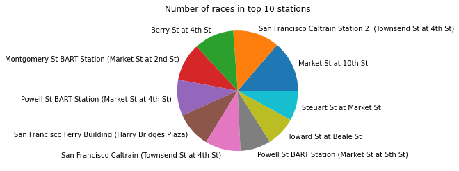

```python
df_sorted = df_sorted.iloc[0:10]
plt.pie(df_sorted, labels=df_sorted.index);
plt.title('Number of races in top 10 stations')
```

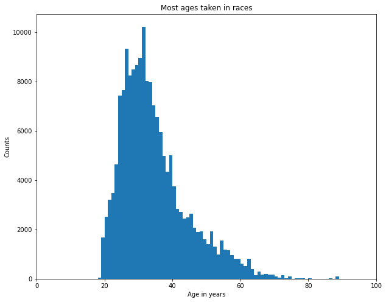

```python
# Visulization shows ages of people participate in races
df['age'] = 2019 - df['member_birth_year']
binsize = 1

display_histplot(df, 'age', binsize, 'Age in years', 'Counts', 'Most ages taken in races')
plt.xlim(0, 100);
```

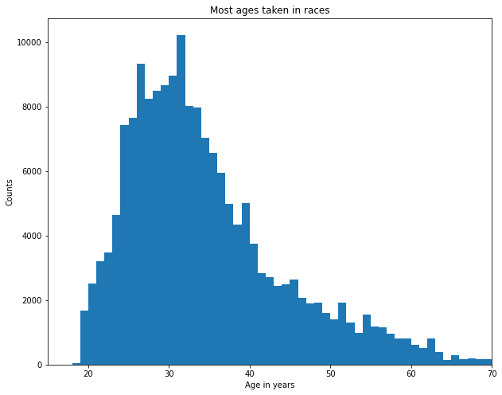

```python
# Same vilsulization in more focus
df['age'] = 2019 - df['member_birth_year']
binsize = 1

display_histplot(df, 'age', binsize, 'Age in years', 'Counts', 'Most ages taken in races')
plt.xlim(15, 70);
```

```python
#average ages af participation
df[df['age']<70]['age'].mean()
```

```
34.015331885162745
```

> Most people which participate are around age of 34

```
Subscriber    163544
Customer       19868
Name: user_type, dtype: int64
```

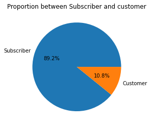

```python
# Proportion for different type of participations
df_gender=df['user_type'].dropna()
df_sorted = df_gender.value_counts()
print(df_sorted)
plt.pie(df_sorted, labels=df_sorted.index, autopct='%1.1f%%');
plt.title('Proportion between Subscriber and customer')
```

> It's abvoius that Subscriber is the most and represent 89.2% of participants

```
No     166053
Yes     17359
Name: bike_share_for_all_trip, dtype: int64
```

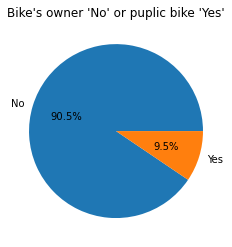

```python
# Proportion for participations who share their bikes and others
df_gender=df['bike_share_for_all_trip'].dropna()
df_sorted = df_gender.value_counts()
print(df_sorted)
plt.pie(df_sorted, labels=df_sorted.index, autopct='%1.1f%%');
plt.title("Bike's owner 'No' or puplic bike 'Yes'")
```

> It's abvoius that most of riders have their biks for the ride and they represent 90.5% of participants

### Of the features you investigated, were there any unusual distributions? Did you perform any operations on the data to tidy, adjust, or change the form of the data? If so, why did you do this?

> Yes i added column for age of rider

## Bivariate Exploration

> In this section, investigate relationships between pairs of variables in your data. Make sure the variables that you cover here have been introduced in some fashion in the previous section (univariate exploration).

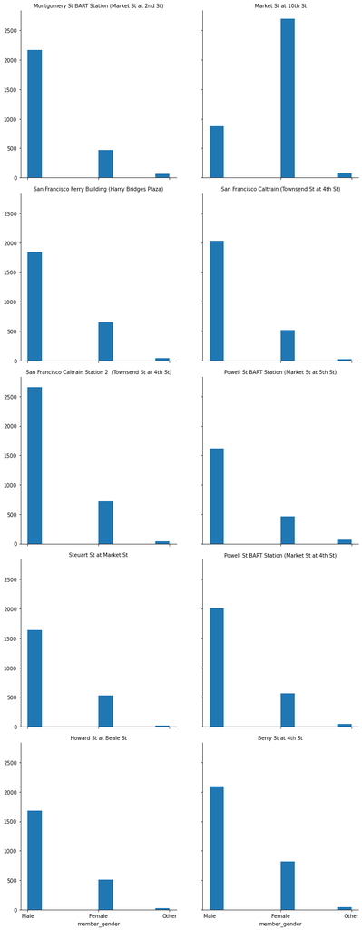

```python
#Visuliztion for each gender in top 10 stations
df_station=df['start_station_name'].dropna()
df_sorted = df_station.value_counts()
most = df_sorted.index[:10]
Top10Stat = df.loc[df['start_station_name'].isin(most)]
g = sb.FacetGrid(data = Top10Stat, col='start_station_name', col_wrap=2, size = 5)
g.map(plt.hist, 'member_gender');
g.set_titles('{col_name}')
```

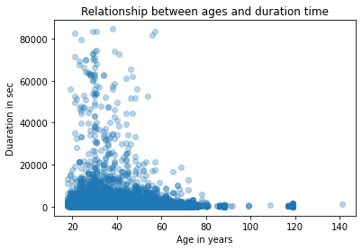

```python
# Relationship between ages and duration of participation
plt.scatter(df['age'], df['duration_sec'], alpha = 0.3)
plt.xlabel('Age in years')
plt.ylabel('Duaration in sec');
plt.title('Relationship between ages and duration time');
```

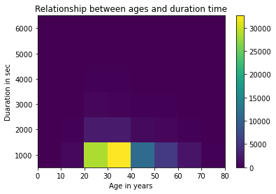

```python
# visuliztion show most ages participate and their duration in race
bins_y = np.arange(500, 7000, 1000)
bins_x = np.arange(0, 90, 10)
plt.hist2d(df['age'], df['duration_sec'], bins = [bins_x, bins_y])
plt.colorbar()
plt.xlabel('Age in years')
plt.ylabel('Duaration in sec');
plt.title('Relationship between ages and duration time');
```

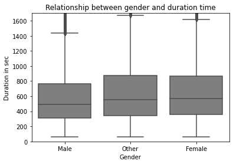

```python
# Boxplot shows relationship between gender and duations
bcolor = sb.color_palette()[7]
sb.boxplot(data = df, x = 'member_gender', y = 'duration_sec', color=bcolor)
plt.ylim(0,1700)
plt.xlabel('Gender')
plt.ylabel('Duration in sec');
plt.title('Relationship between gender and duration time')
```

## Multivariate Exploration

> Create plots of three or more variables to investigate your data even further. Make sure that your investigations are justified, and follow from your work in the previous sections.

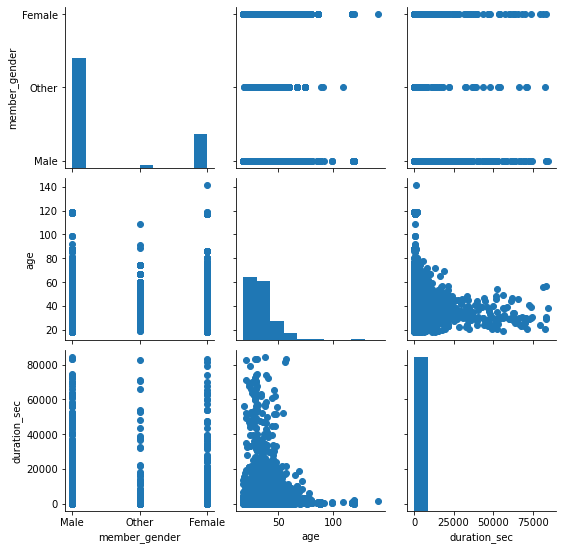

```python
# Visulization for Relation between each member gender and ages and duration time
df_cols = ['member_gender', 'age', 'duration_sec']
g = sb.PairGrid(data = df, vars=df_cols);
g.map_diag(plt.hist)
g.map_offdiag(plt.scatter)
```

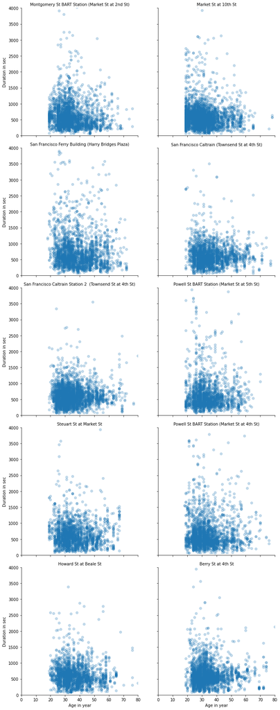

```python
#FacetGrid for relation between ages and durations in top 10 stations
df_station=df['start_station_name'].dropna()
df_sorted = df_station.value_counts()
most = df_sorted.index[:10]
Top10Stat = df.loc[df['start_station_name'].isin(most)]
g = sb.FacetGrid(data = Top10Stat, col='start_station_name', col_wrap=2, size = 5, xlim=[0,80], ylim=[0,4000])
g.map(plt.scatter, 'age', 'duration_sec', alpha=0.25);
g.set_titles('{col_name}')
g.set_xlabels('Age in year')
g.set_ylabels('Duration in sec');
```

> The top ten staions and average of ages of participants and duration of all of them.

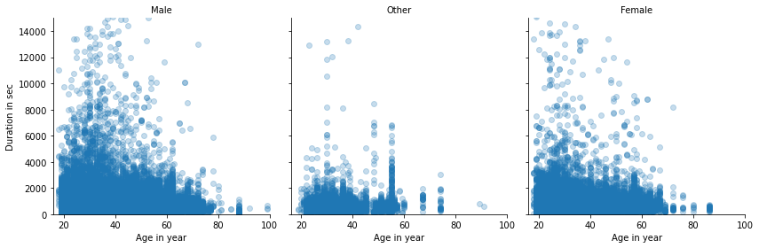

```python
#FacetGrid for relation between ages and durations in top 10 stations
g = sb.FacetGrid(data = df, col='member_gender', col_wrap=3, size = 4, xlim=[16,100], ylim=[0, 15000])
g.map(plt.scatter, 'age', 'duration_sec', alpha=0.25);
g.set_titles('{col_name}')
g.set_xlabels('Age in year')
g.set_ylabels('Duration in sec');
```

### Talk about some of the relationships you observed in this part of the investigation. Were there features that strengthened each other in terms of looking at your feature(s) of interest?

> I noticed here obvious that although the number of trips with higher duration is higher for males but some women around 60 years of age take a longer period of time.

### Were there any interesting or surprising interactions between features?

> May be there exist others.

> At the end of your report, make sure that you export the notebook as an html file from the `File > Download as... > HTML` menu. Make sure you keep track of where the exported file goes, so you can put it in the same folder as this notebook for project submission. Also, make sure you remove all of the quote-formatted guide notes like this one before you finish your report!